# Bike Share Data Exploration

## by Joana

## Investigation Overview

> In this investigation, I'm interested in finding patterns in bike rides on this sharing system. I'll be looking at rides' duration, distance, start time. I'll also consider user types (subscribers/non subscribers).

## Dataset Overview

> This dataset contains information about 3036496 rides between April 2019 and March 2020. For each **ride** there's information about:

> ```
>      - its duration
>      - start time
>      - end time.
> ```

> For the **start and end stations** the dataset has:

> ```
>      - its id
>      - name
>      - latitude
>      - longitude.
> ```

> Finally, there is also information regarding the **bike id, the type of user, whether the user used other means of transports during their trip other than bike or not, and the rental access method**.

## Ride duration and distance

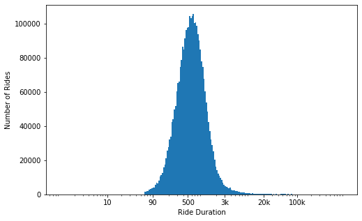

```python
# There's a long tail in the distribution, so let's put it on a log scale instead
log_binsize = 0.025
bins = 10 ** np.arange(0, np.log10(df['duration_sec'].max())+log_binsize, log_binsize)
plt.figure(figsize=[8, 5])
plt.hist(data = df, x = 'duration_sec', bins = bins)
plt.xscale('log')
plt.xticks([10, 90, 500, 3000, 20000, 100000], [10, 90, 500, '3k', '20k', '100k'])
plt.xlabel('Ride Duration')
plt.ylabel('Number of Rides')
plt.show()
```

As for distance, most of the rides are less than 5km.

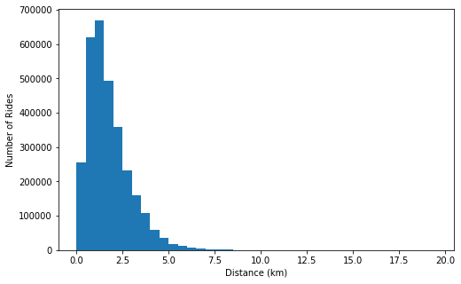

```python
#There seem to be some outliers - let's zoom in the distance
bins = np.arange(0, 20, 0.5)
plt.figure(figsize=[8, 5])
plt.hist(data = df, x = 'distance', bins = bins)
plt.xlabel('Distance (km)')
plt.ylabel('Number of Rides')
plt.show();
```

## User type

> Although the travelled distance for both user types is similar, the averge duration of the ride is higher for Customers (non subscribers)

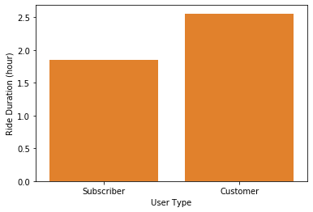

```python
g = sb.barplot(data = df2, x = 'user_type', y = 'duration_hour', color = base_color)
plt.xlabel('User Type')
plt.ylabel('Ride Duration (hour)');
```

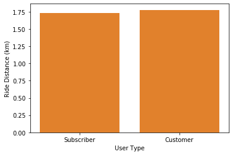

```python
g = sb.barplot(data = df2, x = 'user_type', y = 'distance', color = base_color)
plt.xlabel('User Type')
plt.ylabel('Ride Distance (km)');
```

## Month, Day and Hour

January, February and March are the months with the highest number of rides.

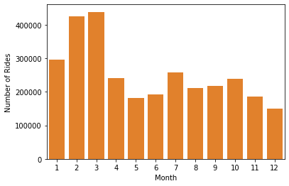

```python
# Standard bar plot - Rides by Month
base_color1 = sb.color_palette()[1]
sb.countplot(data = df, x= "month", color=base_color1);
plt.xlabel('Month')
plt.ylabel('Number of Rides');
```

The number of rides seems to be higher during rush hours (in the morning, between 7am and 9am, and in the afternoon, between 4pm and 7pm)

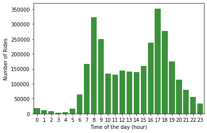

```python
# Standard bar plot - Rides by time of the day (considering start time of the ride)
base_color2 = sb.color_palette()[2]
sb.countplot(data = df, x= "hour", color=base_color2);
plt.xlabel('Time of the day (hour)')
plt.ylabel('Number of Rides');
```

```python
Bike utilization seems to decrease on weekends
```

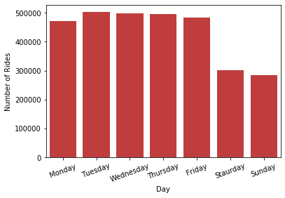

```python
base_color3 = sb.color_palette()[3]
sb.countplot(data = df, x= "day_week", color=base_color3);
plt.xlabel('Day')
plt.ylabel('Number of Rides')
plt.xticks([0, 1, 2, 3, 4, 5, 6], ['Monday', 'Tuesday', 'Wednesday', 'Thursday', 'Friday', 'Staurday', 'Sunday'], rotation=20) ;
```

As weather gets better, Customers seem to take more relaxed rides, as ride duration increases by around one hour, but distance is approximately the same. For subscribers, they keep their routine throughout the year...

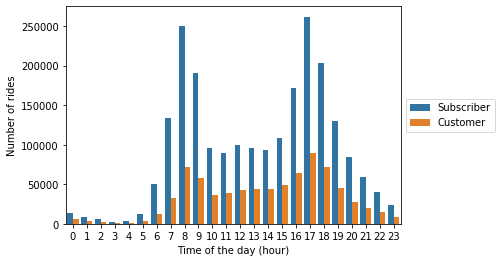

```python
ax = sb.countplot(data = df2, x = 'hour', hue = 'user_type')
ax.legend(loc = 8, ncol = 3, framealpha = 1, title = 'User Type')
plt.xlabel('Time of the day (hour)')
plt.ylabel('Number of rides')
plt.legend(loc = 6, bbox_to_anchor = (1.0, 0.5));
```

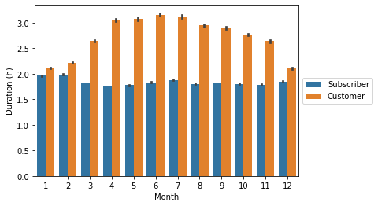

```python
ax = sb.barplot(data = df2, x = 'month', y = 'duration_hour', hue = 'user_type')
ax.legend(loc = 8, ncol = 3, framealpha = 1, title = 'User Type')
plt.xlabel('Month')
plt.ylabel('Duration (h)')
plt.legend(loc = 6, bbox_to_anchor = (1.0, 0.5));
```

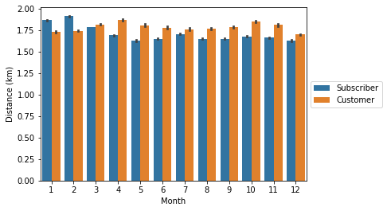

```python
ax = sb.barplot(data = df2, x = 'month', y = 'distance', hue = 'user_type', dodge=0.3)
ax.legend(loc = 8, ncol = 3, framealpha = 1, title = 'User Type')
plt.xlabel('Month')
plt.ylabel('Distance (km)')
plt.legend(loc = 6, bbox_to_anchor = (1.0, 0.5));
```

The same happens on weekends - subscribers mantain their pattern but customers seem to enjoy a longer ride in terms of duration (distance doesn't vary a lot)

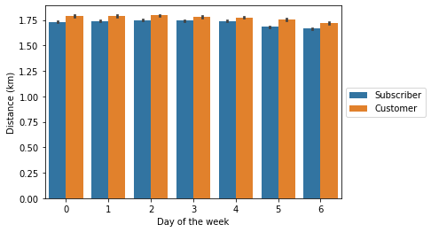

```python
ax = sb.barplot(data = df2, x = 'day_week', y = 'distance', hue = 'user_type')
ax.legend(loc = 8, ncol = 3, framealpha = 1, title = 'User Type');
plt.xlabel('Day of the week')
plt.ylabel('Distance (km)')
plt.legend(loc = 6, bbox_to_anchor = (1.0, 0.5));
```

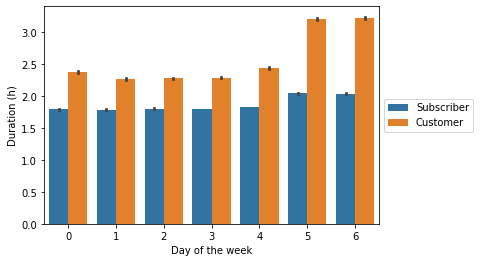

```python
ax = sb.barplot(data = df2, x = 'day_week', y = 'duration_hour', hue = 'user_type')
ax.legend(loc = 8, ncol = 3, framealpha = 1, title = 'User Type')
plt.xlabel('Day of the week')
plt.ylabel('Duration (h)')
plt.legend(loc = 6, bbox_to_anchor = (1.0, 0.5));
```